# Machine Learning Example

Gary R Seamans

April 2018

```r
library(prettydoc)
library(ggplot2)
library(ggRandomForests)
library(caret)
library(knitr)
library(rpart)
library(e1071)
library(naivebayes)
#suppressMessages(library(rattle))
library(rattle)
library(randomForest)
set.seed(500)
```

# Project Description

In this project the goal is to use data from accelerometers on the belt, forearm, arm, and dumbell of 6 participants to predict the manner in which the participants did each exercise. They were asked to perform barbell lifts correctly and incorrectly in 5 different ways. More information is available from the website here: [Weight Lifting Data Description](http://web.archive.org/web/20161224072740/http:/groupware.les.inf.puc-rio.br/har) (see the section on the Weight Lifting Exercise Dataset).

# Loading the data

The data sets were downloaded to a local directory from:

- [Training Data](https://d396qusza40orc.cloudfront.net/predmachlearn/pml-training.csv)
- [Test Data](https://d396qusza40orc.cloudfront.net/predmachlearn/pml-testing.csv)

```r
wt_training <- read.csv(file = "./data/pml-training.csv")
wt_test <- read.csv(file = "./data/pml-testing.csv")
```

# Exploratory Data Analysis and Cleaning

Intial analysis shows that there were 100 columns containing NAs. Once these were removed from the data sets 60 columns remained. Of these 60 columns, 7 contained data unrelated to accelerometer measurements and were removed leaving 53 columns in the training and test sets.

```r
# Data dimensions
dim(wt_training)
```

```
## [1] 19622   160
```

```r
dim(wt_test)
```

```
## [1]  20 160
```

```r
# Check for columns containing NAs
naColumns <- colnames(wt_test)[colSums(is.na(wt_test)) > 0]
length(naColumns)
```

```
## [1] 100
```

```r
# Remove columns with only NAs
wtc_test <- wt_test[, !names(wt_test) %in% naColumns]
wtc_train <- wt_training[, !names(wt_training) %in% naColumns]
dim(wtc_test)
```

```
## [1] 20 60
```

```r
dim(wtc_train)
```

```
## [1] 19622    60
```

```r
# Names of remaining columns
names(wtc_train)
```

```
##  [1] "X"                    "user_name"            "raw_timestamp_part_1"
##  [4] "raw_timestamp_part_2" "cvtd_timestamp"       "new_window"
##  [7] "num_window"           "roll_belt"            "pitch_belt"
## [10] "yaw_belt"             "total_accel_belt"     "gyros_belt_x"
## [13] "gyros_belt_y"         "gyros_belt_z"         "accel_belt_x"
## [16] "accel_belt_y"         "accel_belt_z"         "magnet_belt_x"
## [19] "magnet_belt_y"        "magnet_belt_z"        "roll_arm"
## [22] "pitch_arm"            "yaw_arm"              "total_accel_arm"
## [25] "gyros_arm_x"          "gyros_arm_y"          "gyros_arm_z"
## [28] "accel_arm_x"          "accel_arm_y"          "accel_arm_z"
## [31] "magnet_arm_x"         "magnet_arm_y"         "magnet_arm_z"
## [34] "roll_dumbbell"        "pitch_dumbbell"       "yaw_dumbbell"
## [37] "total_accel_dumbbell" "gyros_dumbbell_x"     "gyros_dumbbell_y"
## [40] "gyros_dumbbell_z"     "accel_dumbbell_x"     "accel_dumbbell_y"
## [43] "accel_dumbbell_z"     "magnet_dumbbell_x"    "magnet_dumbbell_y"
## [46] "magnet_dumbbell_z"    "roll_forearm"         "pitch_forearm"
## [49] "yaw_forearm"          "total_accel_forearm"  "gyros_forearm_x"
## [52] "gyros_forearm_y"      "gyros_forearm_z"      "accel_forearm_x"
## [55] "accel_forearm_y"      "accel_forearm_z"      "magnet_forearm_x"
## [58] "magnet_forearm_y"     "magnet_forearm_z"     "classe"
```

```r
# Remove columns unrelated to accelerometer readings
rm_names <- c("X", "user_name", "raw_timestamp_part_1", "raw_timestamp_part_2",
              "cvtd_timestamp", "new_window", "num_window")
wtc_test <- wtc_test[, !names(wtc_test) %in% rm_names]
wtc_train <- wtc_train[, !names(wtc_train) %in% rm_names]
dim(wtc_test)
```

```
## [1] 20 53
```

```r
dim(wtc_train)
```

```
## [1] 19622    53
```

```r
# Change all of the classes, except *classe* to numeric
wtc_train[1:52] <- lapply(wtc_train[1:52], as.numeric)
wtc_test[1:52] <- lapply(wtc_test[1:52], as.numeric)
# Get rid of the ID column
wtc_test <- wtc_test[1:52]
```

# Partioning

The *wtc_trainig* set was partioned into *train* and *test* datsets. These data sets will be used for training and testing each of the models.

```r
# Create the partitions
train_part <- createDataPartition(y = wtc_train$classe, p = 0.7, list = FALSE)
train <- wtc_train[train_part,]
test <- wtc_train[-train_part,]
# Make all of the columns of interest the same class
train[1:52] <- lapply(train[1:52], as.numeric)
test[1:52] <- lapply(test[1:52], as.numeric)
# Remove *classe* from the test set
#test <- test[,-53]

dim(train)
```

```
## [1] 13737    53
```

```r
dim(test)
```

```
## [1] 5885   53
```

# Modeling and Testing

Three different methods were used: - Random Forests - Naive Bayes - Boosting with trees (gbm)

## Random Forest, Naive Bayes, and Boosting with trees models.

```r
# Create the Random Forest
set.seed(1313)
rf_fit <- randomForest(classe ~ ., data = train)
rf_pred <- predict(rf_fit, test, type = "class")
# Confusion matrix for the random forest
confusionMatrix(rf_pred, test$classe)
```

```
## Confusion Matrix and Statistics
##
##           Reference
## Prediction    A    B    C    D    E
##          A 1673   11    0    0    0
##          B    1 1126    8    0    0
##          C    0    2 1015    9    0
##          D    0    0    3  954    0
##          E    0    0    0    1 1082
##
## Overall Statistics
##
##                Accuracy : 0.9941
##                  95% CI : (0.9917, 0.9959)
##     No Information Rate : 0.2845
##     P-Value [Acc > NIR] : < 2.2e-16
##
##                   Kappa : 0.9925
##  Mcnemar's Test P-Value : NA
##
## Statistics by Class:
##
##                      Class: A Class: B Class: C Class: D Class: E
## Sensitivity            0.9994   0.9886   0.9893   0.9896   1.0000
## Specificity            0.9974   0.9981   0.9977   0.9994   0.9998
## Pos Pred Value         0.9935   0.9921   0.9893   0.9969   0.9991
## Neg Pred Value         0.9998   0.9973   0.9977   0.9980   1.0000
## Prevalence             0.2845   0.1935   0.1743   0.1638   0.1839
## Detection Rate         0.2843   0.1913   0.1725   0.1621   0.1839
## Detection Prevalence   0.2862   0.1929   0.1743   0.1626   0.1840
## Balanced Accuracy      0.9984   0.9933   0.9935   0.9945   0.9999
```

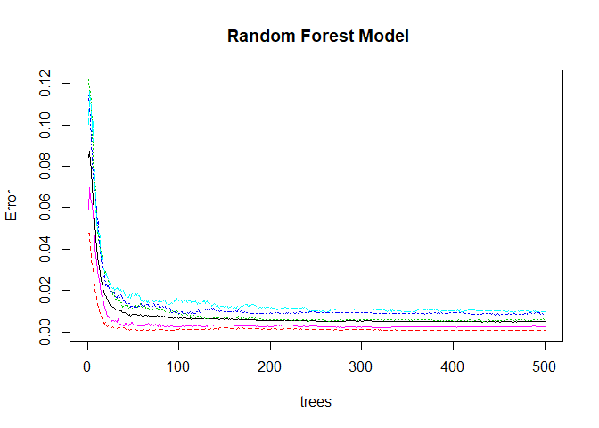

```r
plot(rf_fit, main = " Random Forest Model")
```

```r
# Test it on the validation set

# Create a Naive Bayes classifier
nb_model <- naive_bayes(classe ~ ., data = train)
nb_predict <- predict(nb_model, test)
confusionMatrix(nb_predict, test$classe)
```

```
## Confusion Matrix and Statistics
##
##           Reference
## Prediction    A    B    C    D    E
##          A 1061  124  238   94   54
##          B  101  715  107   24  239
##          C  288  160  518  257   94
##          D  188   85  128  461  143
##          E   36   55   35  128  552
##
## Overall Statistics
##
##                Accuracy : 0.5619
##                  95% CI : (0.5491, 0.5747)
##     No Information Rate : 0.2845
##     P-Value [Acc > NIR] : < 2.2e-16
##
##                   Kappa : 0.4475
##  Mcnemar's Test P-Value : < 2.2e-16
##
## Statistics by Class:
##
##                      Class: A Class: B Class: C Class: D Class: E
## Sensitivity            0.6338   0.6277  0.50487  0.47822   0.5102
## Specificity            0.8789   0.9008  0.83556  0.88945   0.9471
## Pos Pred Value         0.6754   0.6029  0.39332  0.45871   0.6849
## Neg Pred Value         0.8579   0.9098  0.88879  0.89693   0.8956
## Prevalence             0.2845   0.1935  0.17434  0.16381   0.1839
## Detection Rate         0.1803   0.1215  0.08802  0.07833   0.0938
## Detection Prevalence   0.2669   0.2015  0.22379  0.17077   0.1370
## Balanced Accuracy      0.7563   0.7643  0.67022  0.68383   0.7286
```

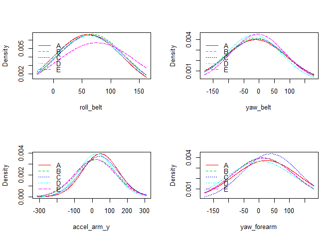

```r
# Plot examples of the marginal probabilities, only four were selected for the examples.
par(mfrow=c(2,2))
plot(nb_model, which = c("roll_belt","yaw_belt","accel_arm_y","yaw_forearm"))
```

```r
par(mfrow=c(1,1))
# Boosting with trees *gbm*
boost_model <- train(classe ~ ., method = "gbm", data = train, verbose = FALSE)
boost_predict <- predict(boost_model, test)
confusionMatrix(boost_predict, test$classe)
```

```
## Confusion Matrix and Statistics
##
##           Reference
## Prediction    A    B    C    D    E
##          A 1643   33    0    3    2
##          B   17 1075   27    2   16
##          C    6   22  981   25   10
##          D    7    7   17  923   13
##          E    1    2    1   11 1041
##
## Overall Statistics
##
##                Accuracy : 0.9623
##                  95% CI : (0.9571, 0.967)
##     No Information Rate : 0.2845
##     P-Value [Acc > NIR] : < 2.2e-16
##
##                   Kappa : 0.9523
##  Mcnemar's Test P-Value : 7.521e-05
##
## Statistics by Class:
##
##                      Class: A Class: B Class: C Class: D Class: E
## Sensitivity            0.9815   0.9438   0.9561   0.9575   0.9621
## Specificity            0.9910   0.9869   0.9870   0.9911   0.9969
## Pos Pred Value         0.9774   0.9455   0.9397   0.9545   0.9858
## Neg Pred Value         0.9926   0.9865   0.9907   0.9917   0.9915
## Prevalence             0.2845   0.1935   0.1743   0.1638   0.1839
## Detection Rate         0.2792   0.1827   0.1667   0.1568   0.1769
## Detection Prevalence   0.2856   0.1932   0.1774   0.1643   0.1794
## Balanced Accuracy      0.9862   0.9654   0.9716   0.9743   0.9795
```

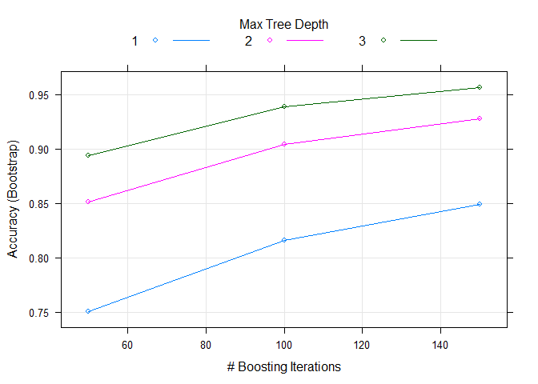

```r
plot(boost_model)
```

# Test Data predictions

The best result was using Random Forests so that is what I used for the test data set.

```r
test_prediction <-  predict(rf_fit, wtc_test, type = "class")
test_prediction
```

```
##  1  2  3  4  5  6  7  8  9 10 11 12 13 14 15 16 17 18 19 20
##  B  A  B  A  A  E  D  B  A  A  B  C  B  A  E  E  A  B  B  B
## Levels: A B C D E
```